# Desafio 11

Author

Julia Folgueral - RA: 277178

```
Este arquivo foi gerado em: 07/10/2025 11:14:31
```

```r
# Carregar a biblioteca reticulate para usar o python
#library(reticulate)
```

```python
# Instalar bibliotecas
#!pip install polars
#!pip install pandas
```

```python
# Importar o polars
import polars as pl
```

1. Utilizando o arquivo renda_adulta.csv e sabendo que ele não possui cabeçalho, faça a importação do banco de dados utilizando os nomes das colunas conforme apresentado acima e na sequência ali indicada. No momento da importação do arquivo, você deve, também, indicar os tipos de cada uma das colunas. Utilize o fato de que o símbolo ? representa valores faltantes.

```python
# Lista de nomes das colunas
colunas = [
    "age", "workclass", "fnlwgt", "education", "education-num",
    "marital-status", "occupation", "relationship", "race", "sex",
    "capital-gain", "capital-loss", "hours-per-week",
    "native-country", "income"
]

# Especificação dos tipos de cada coluna
tipos = {
    "age": pl.Int64,
    "workclass": pl.Categorical,
    "fnlwgt": pl.Int64,
    "education": pl.Categorical,
    "education-num": pl.Int64,
    "marital-status": pl.Categorical,
    "occupation": pl.Categorical,
    "relationship": pl.Categorical,
    "race": pl.Categorical,
    "sex": pl.Categorical,
    "capital-gain": pl.Int64,
    "capital-loss": pl.Int64,
    "hours-per-week": pl.Int64,
    "native-country": pl.Categorical,
    "income": pl.Categorical
}

# Leitura do arquivo CSV compactado
renda = pl.read_csv(
    "renda_adulta.csv.gz",
    has_header=False,      # sem cabeçalho
    new_columns=colunas,   # nomes das colunas
    null_values="?",       # trata "?" como valor ausente
    dtypes=tipos,          # tipos das colunas
    infer_schema_length=0, # força o uso dos tipos fornecidos
)
# Visualizar as primeiras linhas
renda.head()
```

shape: (5, 15)

| age i64 | workclass cat | fnlwgt i64 | education cat | education-num i64 | marital-status cat | occupation cat | relationship cat | race cat | sex cat | capital-gain i64 | capital-loss i64 | hours-per-week i64 | native-country cat | income cat |
| --- | --- | --- | --- | --- | --- | --- | --- | --- | --- | --- | --- | --- | --- | --- |
| 39 | "State-gov" | 77516 | "Bachelors" | 13 | "Never-married" | "Adm-clerical" | "Not-in-family" | "White" | "Male" | 2174 | 0 | 40 | "United-States" | "<=50K" |
| 50 | "Self-emp-not-inc" | 83311 | "Bachelors" | 13 | "Married-civ-spouse" | "Exec-managerial" | "Husband" | "White" | "Male" | 0 | 0 | 13 | "United-States" | "<=50K" |
| 38 | "Private" | 215646 | "HS-grad" | 9 | "Divorced" | "Handlers-cleaners" | "Not-in-family" | "White" | "Male" | 0 | 0 | 40 | "United-States" | "<=50K" |
| 53 | "Private" | 234721 | "11th" | 7 | "Married-civ-spouse" | "Handlers-cleaners" | "Husband" | "Black" | "Male" | 0 | 0 | 40 | "United-States" | "<=50K" |
| 28 | "Private" | 338409 | "Bachelors" | 13 | "Married-civ-spouse" | "Prof-specialty" | "Wife" | "Black" | "Female" | 0 | 0 | 40 | "Cuba" | "<=50K" |

2. Apresente os tipos de cada uma das coluna.

```python
# Mostra o nome das colunas e seus respectivos tipos
renda.schema
```

```
Schema({'age': Int64, 'workclass': Categorical, 'fnlwgt': Int64, 'education': Categorical, 'education-num': Int64, 'marital-status': Categorical, 'occupation': Categorical, 'relationship': Categorical, 'race': Categorical, 'sex': Categorical, 'capital-gain': Int64, 'capital-loss': Int64, 'hours-per-…
```

3. Apresente as dimensões da tabela de dados.

```python
# Mostra o número de linhas e de colunas (n_linhas, n_colunas)
renda.shape
```

```
(32561, 15)
```

4. Quantas pessoas recebem acima de $50.000 e quantas pessoas recebem abaixo deste limiar?

```python
# agrupa por renda e conta a quantidade de pessoas em cada categoria
renda.group_by("income").count().sort("count", descending=True)
```

shape: (2, 2)

| income cat | count u32 |
| --- | --- |
| "<=50K" | 24720 |
| ">50K" | 7841 |

5. Crie um objeto chamado renda_longo, no qual você transforma as colunas capital-gain e capital-loss (formato wide) para formato longo. Os valores destas variáveis devem ser armazenados numa nova coluna chamada Valor e os tipos de valores (gain e loss) devem ser armazenados numa coluna chamada tipo.

```python
renda_longo = renda.melt(
    id_vars=[  # colunas que não mudam
        "age", "workclass", "fnlwgt", "education", "education-num",
        "marital-status", "occupation", "relationship", "race", "sex",
        "hours-per-week", "native-country", "income"
    ],
    value_vars=["capital-gain", "capital-loss"],  # colunas que serão empilhadas
    variable_name="tipo",   # nome da nova coluna que indica o tipo
    value_name="Valor"      #
)
# Deixar os nomes confrome pedido no enunciado
renda_longo = renda_longo.with_columns(
    pl.col("tipo").str.replace("capital-", "")
)

# Visualizar as primeiras linhas
renda_longo.head()
```

shape: (5, 15)

| age i64 | workclass cat | fnlwgt i64 | education cat | education-num i64 | marital-status cat | occupation cat | relationship cat | race cat | sex cat | hours-per-week i64 | native-country cat | income cat | tipo str | Valor i64 |
| --- | --- | --- | --- | --- | --- | --- | --- | --- | --- | --- | --- | --- | --- | --- |
| 39 | "State-gov" | 77516 | "Bachelors" | 13 | "Never-married" | "Adm-clerical" | "Not-in-family" | "White" | "Male" | 40 | "United-States" | "<=50K" | "gain" | 2174 |
| 50 | "Self-emp-not-inc" | 83311 | "Bachelors" | 13 | "Married-civ-spouse" | "Exec-managerial" | "Husband" | "White" | "Male" | 13 | "United-States" | "<=50K" | "gain" | 0 |
| 38 | "Private" | 215646 | "HS-grad" | 9 | "Divorced" | "Handlers-cleaners" | "Not-in-family" | "White" | "Male" | 40 | "United-States" | "<=50K" | "gain" | 0 |
| 53 | "Private" | 234721 | "11th" | 7 | "Married-civ-spouse" | "Handlers-cleaners" | "Husband" | "Black" | "Male" | 40 | "United-States" | "<=50K" | "gain" | 0 |
| 28 | "Private" | 338409 | "Bachelors" | 13 | "Married-civ-spouse" | "Prof-specialty" | "Wife" | "Black" | "Female" | 40 | "Cuba" | "<=50K" | "gain" | 0 |

6. Quais são as médias de horas trabalhadas por classe salarial?

```python
# Agrupa pela classe salarial
renda.group_by("income").agg(
    pl.col("hours-per-week").mean().alias("media_horas")
)
```

shape: (2, 2)

| income cat | media_horas f64 |
| --- | --- |
| "<=50K" | 38.84021 |
| ">50K" | 45.473026 |

```python
# Dentro de cada grupo (<=50K e >50K), calcula a média da coluna 'hours-per-week' função .mean() faz a média e .alias("media_horas") dá um nome à nova coluna resultante.
```

7. Se cada linha representa uma pessoa, quantas pessoas foram amostradas em cada profissão?

```python
# Agrupa pela coluna "occupation", conta quantas linhas (=pessoas) em cada occupation e ordena de forma decrescente
renda.group_by("occupation").count().sort("count", descending=True)
```

shape: (15, 2)

| occupation cat | count u32 |
| --- | --- |
| "Prof-specialty" | 4140 |
| "Craft-repair" | 4099 |
| "Exec-managerial" | 4066 |
| "Adm-clerical" | 3770 |
| "Sales" | 3650 |
| … | … |
| "Farming-fishing" | 994 |
| "Tech-support" | 928 |
| "Protective-serv" | 649 |
| "Priv-house-serv" | 149 |
| "Armed-Forces" | 9 |

8. Crie um gráfico de barras que apresente o número médio de horas trabalhadas semanalmente em função do nível salarial.

```python
# Instalar matplotlib
#!pip install matplotlib
```

```python
import matplotlib
matplotlib.use("Agg")

import matplotlib.pyplot as plt
```

```python
# Calcula a média de horas por classe salarial
media_horas = (
    renda.group_by("income")
         .agg(pl.col("hours-per-week").mean().alias("media_horas"))
         .sort("income")  # opcional: ordenar por salário
)

# Faz conversões para usar listas para o matplotlib
salario = media_horas["income"].to_list()
horas = media_horas["media_horas"].to_list()

# Gráfico de barras
plt.figure(figsize=(6,4))
plt.bar(salario, horas, color=["darkblue", "blue"])
plt.xlabel("Classe Salarial")
plt.ylabel("Média de horas trabalhadas por semana")
plt.title("Média de horas trabalhadas por semana por nível salarial")
plt.ylim(0, max(horas)+5)  # deixa um espaço acima das barras
```

```
(0.0, 50.473026399693914)
```

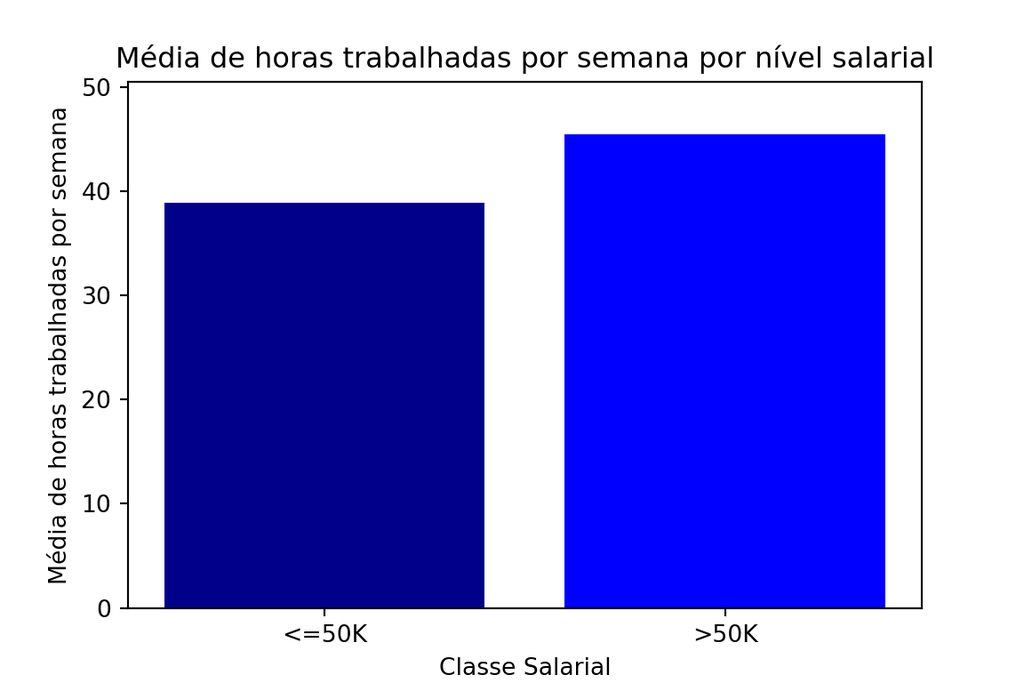

```python
plt.show()
```

9. Desafio: existe alguma evidência de discriminação salarial entre gêneros biológicos?

```python
# Total de pessoas por gênero
sexo_total = (
    renda.group_by("sex")
         .agg(pl.count().alias("total"))
)
# Total de pessoas com renda >50K por gênero
sexo_maior50k = (
    renda.filter(pl.col("income") == ">50K")
         .group_by("sex")
         .agg(pl.count().alias("maior50k"))
)
# Junta os dois resultados de cima
proporcao = sexo_total.join(sexo_maior50k, on="sex", how="left")

# Calcula a porcentagem de pessoas com renda >50K por gênero
proporcao = proporcao.with_columns(
    (pl.col("maior50k") / pl.col("total") * 100).alias("percentual_>50K")
)

# Mostra a proporção
proporcao.select(["sex", "percentual_>50K"])
```

shape: (2, 2)

| sex cat | percentual_>50K f64 |
| --- | --- |
| "Male" | 30.573658 |
| "Female" | 10.946059 |

Apenas cerca de 10% das mulheres ganham acima de 50k por ano, enquanto cerca de 30% dos homens ganham acima do mesmo valor. Isso indica uma grande diferença salarial entre os genêros, trazendo evidência de discriminção salarial entre os genêros biológicos.